# Data Cleaning And Analysis

## Problem Definition

Film production is a high-risk investment activity, where large financial commitments are made under significant uncertainty about audience preferences and market response. Producers must decide on critical factors such as genre, runtime, and content style without clear, data-backed evidence of what drives movie success.

Despite the availability of public platforms like IMDb that capture audience ratings and popularity metrics, these signals are often conflicting—some movies receive high ratings but limited popularity, while others attract massive audiences despite average ratings. This ambiguity makes it difficult for producers to make informed investment decisions.

This project aims to leverage IMDb data to identify patterns and relationships between movie characteristics and audience response, thereby reducing uncertainty in production planning.

## Business Problem Statement

Vamshi,a movie producer with a limited production budget, wants to invest in his next film while maximizing the probability of success and minimizing financial risk.

However, he faces multiple uncertainties:

- Which movie genres are more likely to be well-received by audiences
- What movie duration provides the best balance between engagement and satisfaction
- Whether traditional storytelling styles still resonate with modern audiences
- Whether high IMDb ratings reliably translate into high audience popularity

The absence of clear, data-driven guidance makes these decisions speculative and increases the likelihood of investment failure.

## Business Questions

**Genre Preference :** Which movie genres are most consistently associated with higher audience ratings?

**Runtime Optimization :** What movie duration range yields the most stable and favorable audience response?

**Popularity vs Quality :** Is there a strong relationship between IMDb ratings and movie popularity (votes)?

**Audience Behavior :** Do highly rated movies always attract high audience engagement?

**Strategic Risk :** Which combination of movie attributes offers a safer investment choice for producers with budget constraints?

## Project Objectives

- To collect and construct a structured IMDb movie dataset

> by scraping publicly available movie information, including ratings, vote counts, genres, runtime, and release year.
- To perform data cleaning and preprocessing

> to ensure consistency, eliminate missing values, and prepare the dataset for reliable analysis.
- To analyze genre-wise audience acceptance

> by examining rating distributions and identifying genres that consistently receive higher audience appreciation.
- To study the relationship between movie ratings and popularity

> to statistically validate key relationships between movie attributes such as genre, runtime, popularity, and ratings.
- To derive actionable, data-driven insights

> that can support movie producers in selecting safer, high-potential movie concepts under budget constraints.

```python
import pandas as pd
import matplotlib.pyplot as plt
import seaborn as sns
```

```python
import pandas as pd
df = pd.read_csv(r"E:\EDA\project\imdb_2000_movies.csv")
```

```python
df
```

|  | url | imdb_id | language | title | genre | certificate | runtime_minutes | summary | imdb_rating | votes | director | stars | year |
| --- | --- | --- | --- | --- | --- | --- | --- | --- | --- | --- | --- | --- | --- |
| 0 | https://www.imdb.com/title/tt33503920/ | tt33503920 | Gujarati | Hu Tara Vina Kai Nai | Romance | NaN | 125.0 | Hu Tara Vina Kai Nai" revolves around a newly ... | 9.3 | 16.0 | Dhruval Sodagar | Umesh Barot, Rubina Belim, Kuldeep Mishra | 2024.0 |
| 1 | https://www.imdb.com/title/tt7255568/ | tt7255568 | Hindi | Student of The Year 2 | Action, Comedy, Drama | Not Rated | 146.0 | A student must face off against bullies and ov... | 2.2 | 23778.0 | Punit Malhotra | Tiger Shroff, Ananya Panday, Tara Sutaria | 2019.0 |
| 2 | https://www.imdb.com/title/tt28258888/ | tt28258888 | Telugu | Matka | Action, Crime, Drama | NaN | 156.0 | Rising through the ranks of the criminal world... | 4.7 | 891.0 | Karuna Kumar | Varun Tej, Meenaakshi Chaudhary, Nora Fatehi | 2024.0 |
| 3 | https://www.imdb.com/title/tt1857670/ | tt1857670 | Tamil | Deiva Thirumagal | Drama, Family, Musical | Not Rated | 166.0 | A man with disabilities fights for custody of ... | 8.2 | 7122.0 | N Kumar, A.L. Vijay | Vikram, Anushka Shetty, Amala Paul | 2011.0 |
| 4 | https://www.imdb.com/title/tt1392190/ | tt1392190 | English, Russian | Mad Max: Fury Road | Action, Adventure, Sci-Fi | R | 120.0 | In a post-apocalyptic wasteland, a woman rebel... | 8.1 | 1194440.0 | George Miller | Tom Hardy, Charlize Theron, Nicholas Hoult | 2015.0 |
| ... | ... | ... | ... | ... | ... | ... | ... | ... | ... | ... | ... | ... | ... |
| 1995 | https://www.imdb.com/title/tt10340562/ | tt10340562 | Tamil | Etharkkum Thunindhavan | Action, Crime, Drama | NaN | 151.0 | A lawyer turns judge jury and executioner and ... | 6.4 | 14062.0 | Pandiraaj | Suriya, Priyanka Arulmohan, Sathyaraj | 2022.0 |
| 1996 | https://www.imdb.com/title/tt0047269/ | tt0047269 | Bengali | Naramedh Yagna | Drama | NaN | NaN | NaN | 9.2 | 10.0 | Ritwik Ghatak, Bijan Sen | Ajit Bandyopadhyay, Mihir Bhattacharya, Tulsi ... | 1954.0 |
| 1997 | https://www.imdb.com/title/tt7767866/ | tt7767866 | Telugu | Chal Mohan Ranga | Romance | NaN | 148.0 | Mohan Ranga falls in love with Megha Subramany... | 5.9 | 1493.0 | Krishna Chaitanya | Nithiin, Megha Akash, Madhunandan | 2018.0 |
| 1998 | https://www.imdb.com/title/tt8427708/ | tt8427708 | Gujarati | Toh Lagi Sharat | Comedy, Mystery, Thriller | NaN | 137.0 | A bet between two friends turns so ugly giving... | 9.2 | 51.0 | Nitin N Vaidya | Ronit Vaidya, Priyank Gajjar, Jignesh Modi | 2018.0 |
| 1999 | https://www.imdb.com/title/tt32843405/ | tt32843405 | NaN | Anartha | Thriller | NaN | 127.0 | With the backdrop of serial suspected suicides... | 9.2 | 220.0 | Ramesh Krishna | Ganesh Ds, Vishal Mannur, Rakshith | 2024.0 |

2000 rows × 13 columns

```python
df.shape
```

```
(2000, 13)
```

```python
df.columns
```

```
Index(['url', 'imdb_id', 'language', 'title', 'genre', 'certificate',
       'runtime_minutes', 'summary', 'imdb_rating', 'votes', 'director',
       'stars', 'year'],
      dtype='object')
```

```python
df.dtypes
```

```
url                 object
imdb_id             object
language            object
title               object
genre               object
certificate         object
runtime_minutes    float64
summary             object
imdb_rating        float64
votes              float64
director            object
stars               object
year               float64
dtype: object
```

```python
df.isna().sum()
```

```
url                   0
imdb_id               0
language             32
title                 0
genre               155
certificate        1442
runtime_minutes     237
summary             153
imdb_rating         149
votes               149
director              7
stars                21
year                153
dtype: int64
```

### Data Cleaning

```python
df.info()
```

```
<class 'pandas.core.frame.DataFrame'>
RangeIndex: 2000 entries, 0 to 1999
Data columns (total 13 columns):
 #   Column           Non-Null Count  Dtype
---  ------           --------------  -----
 0   url              2000 non-null   object
 1   imdb_id          2000 non-null   object
 2   language         1968 non-null   object
 3   title            2000 non-null   object
 4   genre            1845 non-null   object
 5   certificate      558 non-null    object
 6   runtime_minutes  1763 non-null   float64
 7   summary          1847 non-null   object
 8   imdb_rating      1851 non-null   float64
 9   votes            1851 non-null   float64
 10  director         1993 non-null   object
 11  stars            1979 non-null   object
 12  year             1847 non-null   float64
dtypes: float64(4), object(9)
memory usage: 203.3+ KB
```

```python
df["certificate"].value_counts(dropna=False)
```

```
certificate
NaN          1442
Not Rated     328
R              74
PG-13          46
PG             29
TV-MA          27
TV-14          18
Approved       15
G               7
Unrated         4
TV-PG           4
13+             3
Passed          1
16+             1
18+             1
Name: count, dtype: int64
```

```python
df = df.drop(columns=["certificate"])
```

```python
df[["runtime_minutes", "votes", "year"]].describe()
```

|  | runtime_minutes | votes | year |
| --- | --- | --- | --- |
| count | 1763.000000 | 1.851000e+03 | 1847.000000 |
| mean | 135.145207 | 5.748294e+04 | 2015.779643 |
| std | 24.405913 | 2.449628e+05 | 13.262810 |
| min | 16.000000 | 5.000000e+00 | 1927.000000 |
| 25% | 121.000000 | 2.790000e+02 | 2013.000000 |
| 50% | 135.000000 | 2.099000e+03 | 2021.000000 |
| 75% | 150.000000 | 1.128550e+04 | 2024.000000 |
| max | 321.000000 | 3.119931e+06 | 2026.000000 |

```python
df[df["year"] > 2024][["title", "year"]].head()
```

|  | title | year |
| --- | --- | --- |
| 13 | Jockey | 2026.0 |
| 17 | The Constable | 2025.0 |
| 24 | Uyirin Uyire | 2025.0 |
| 30 | Court: State vs. A Nobody | 2025.0 |
| 31 | The Savage | 2025.0 |

```python
df.loc[df["year"] > 2024, "year"] = 2024
```

```python
df[df["runtime_minutes"] < 60][["title", "runtime_minutes"]].head(10)
```

|  | title | runtime_minutes |
| --- | --- | --- |
| 451 | The Yakshagana Puppets | 45.0 |
| 694 | Five Rivers Still Thirsty: Based on Water Prob... | 45.0 |
| 701 | Three Worlds, One Stage | 57.0 |
| 727 | Gosain: The colors of Spring | 28.0 |
| 795 | Honey Bunny in Bank Robbery | 47.0 |
| 930 | Lost in Transit | 48.0 |
| 1045 | Fathima The Oracle | 51.0 |
| 1049 | The Saroj Khan Story | 52.0 |
| 1157 | Honey Bunny in Crazy Crazy Chase | 50.0 |
| 1173 | Gutter Boy | 58.0 |

```python
df["votes"].quantile([0.5, 0.9, 0.95, 0.99])
```

```
0.50       2099.0
0.90      50755.0
0.95     240172.0
0.99    1296627.0
Name: votes, dtype: float64
```

```python
df["runtime_minutes"] = df["runtime_minutes"].fillna(df["runtime_minutes"].median())
```

```python
df["imdb_rating"] = df["imdb_rating"].fillna(df["imdb_rating"].median())
```

```python
df["votes"] = df["votes"].fillna(df["votes"].median())
```

```python
df.isna().sum()
```

```
url                  0
imdb_id              0
language            32
title                0
genre              155
runtime_minutes      0
summary            153
imdb_rating          0
votes                0
director             7
stars               21
year               153
dtype: int64
```

```python
df["year"] = df["year"].fillna(df["year"].median())
```

```python
categorical_colums = ["language", "genre", "summary", "director", "stars"]
df[categorical_colums] = df[categorical_colums].fillna("Unknown")
```

```python
df.isna().sum()
```

```
url                0
imdb_id            0
language           0
title              0
genre              0
runtime_minutes    0
summary            0
imdb_rating        0
votes              0
director           0
stars              0
year               0
dtype: int64
```

## UNIVARIATE ANALYSIS

```python
df["imdb_rating"].describe()
```

```
count    2000.000000
mean        7.170400
std         1.523093
min         1.200000
25%         6.300000
50%         7.300000
75%         8.200000
max        10.000000
Name: imdb_rating, dtype: float64
```

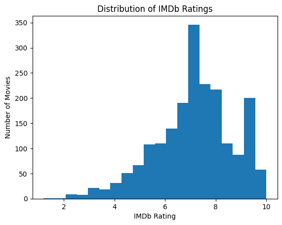

```python
import matplotlib.pyplot as plt

plt.hist(df["imdb_rating"], bins=20)
plt.xlabel("IMDb Rating")
plt.ylabel("Number of Movies")
plt.title("Distribution of IMDb Ratings")
plt.show()
```

```python
df["popularity_level"] = pd.cut(df["votes"],bins=[0, 1000, 10000, 100000, df["votes"].max()],labels=["Low", "Medium", "High", "Very High"])
df["popularity_level"].value_counts()
```

```
popularity_level
Medium       806
Low          702
High         353
Very High    139
Name: count, dtype: int64
```

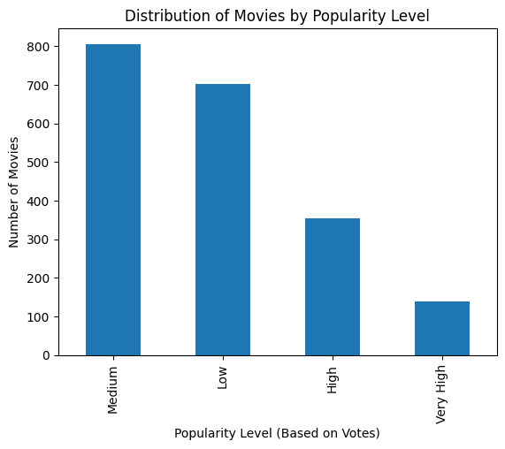

```python
df["popularity_level"].value_counts().plot(kind="bar")
plt.xlabel("Popularity Level (Based on Votes)")
plt.ylabel("Number of Movies")
plt.title("Distribution of Movies by Popularity Level")
plt.show()
```

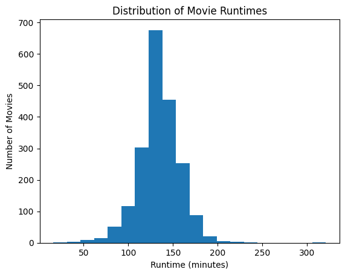

```python
plt.hist(df["runtime_minutes"], bins=20)
plt.xlabel("Runtime (minutes)")
plt.ylabel("Number of Movies")
plt.title("Distribution of Movie Runtimes")
plt.show()
```

```python
df["runtime_bin"] = pd.cut(
    df["runtime_minutes"],
    bins=[0, 90, 120, 150, 180, 1000],
    labels=["Short (<90)", "Medium (90–120)", "Standard (120–150)", "Long (150–180)", "Very Long (>180)"])
```

```python
df["runtime_bin"].value_counts()
```

```
runtime_bin
Standard (120–150)    1135
Long (150–180)         393
Medium (90–120)        362
Short (<90)             71
Very Long (>180)        39
Name: count, dtype: int64
```

# BIVARIATE ANALYSIS

#### Runtime Category vs IMDb Rating

[figure not shown]

```python
runtime_rating = df.groupby("runtime_bin")["imdb_rating"].median()

runtime_rating.plot(kind="bar")
plt.xlabel("Runtime Category")
plt.ylabel("Median IMDb Rating")
plt.title("Median IMDb Rating across Runtime Categories")
plt.show()
```

### Rating Composition across Popularity Levels

```python
df["rating_band"] = pd.cut(
    df["imdb_rating"],
    bins=[0, 5, 7, 10],
    labels=["Low", "Average", "High"]
)
```

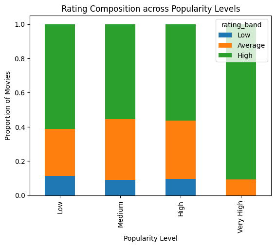

```python
rating_dist = pd.crosstab(
    df["popularity_level"],
    df["rating_band"],
    normalize="index"
)

rating_dist.plot(kind="bar", stacked=True)
plt.xlabel("Popularity Level")
plt.ylabel("Proportion of Movies")
plt.title("Rating Composition across Popularity Levels")
plt.show()
```

### Genre vs Rating

```python
df_genre = df.copy()
df_genre["genre"] = df_genre["genre"].str.split(", ")
df_genre = df_genre.explode("genre")
```

```python
df_genre.head()
```

|  | url | imdb_id | language | title | genre | runtime_minutes | summary | imdb_rating | votes | director | stars | year | popularity_level | runtime_bin | rating_band |
| --- | --- | --- | --- | --- | --- | --- | --- | --- | --- | --- | --- | --- | --- | --- | --- |
| 0 | https://www.imdb.com/title/tt33503920/ | tt33503920 | Gujarati | Hu Tara Vina Kai Nai | Romance | 125.0 | Hu Tara Vina Kai Nai" revolves around a newly ... | 9.3 | 16.0 | Dhruval Sodagar | Umesh Barot, Rubina Belim, Kuldeep Mishra | 2024.0 | Low | Standard (120–150) | High |
| 1 | https://www.imdb.com/title/tt7255568/ | tt7255568 | Hindi | Student of The Year 2 | Action | 146.0 | A student must face off against bullies and ov... | 2.2 | 23778.0 | Punit Malhotra | Tiger Shroff, Ananya Panday, Tara Sutaria | 2019.0 | High | Standard (120–150) | Low |
| 1 | https://www.imdb.com/title/tt7255568/ | tt7255568 | Hindi | Student of The Year 2 | Comedy | 146.0 | A student must face off against bullies and ov... | 2.2 | 23778.0 | Punit Malhotra | Tiger Shroff, Ananya Panday, Tara Sutaria | 2019.0 | High | Standard (120–150) | Low |
| 1 | https://www.imdb.com/title/tt7255568/ | tt7255568 | Hindi | Student of The Year 2 | Drama | 146.0 | A student must face off against bullies and ov... | 2.2 | 23778.0 | Punit Malhotra | Tiger Shroff, Ananya Panday, Tara Sutaria | 2019.0 | High | Standard (120–150) | Low |
| 2 | https://www.imdb.com/title/tt28258888/ | tt28258888 | Telugu | Matka | Action | 156.0 | Rising through the ranks of the criminal world... | 4.7 | 891.0 | Karuna Kumar | Varun Tej, Meenaakshi Chaudhary, Nora Fatehi | 2024.0 | Low | Long (150–180) | Low |

```python
genre_rating = (df_genre.groupby("genre")["imdb_rating"].median().sort_values(ascending=False))
```

[figure not shown]

```python
genre_rating.plot(kind="bar", figsize=(12,5))
plt.xlabel("Genre")
plt.ylabel("Median IMDb Rating")
plt.title("Genre-wise Median IMDb Ratings")
plt.show()
```

## Multivariate Analysis

```python
df["runtime_bin"] = pd.cut(
    df["runtime_minutes"],
    bins=[0, 90, 120, 150, 180, 1000],
    labels=["<90", "90–120", "120–150", "150–180", ">180"])

pivot_rt_pop = df.pivot_table(values="imdb_rating",index="runtime_bin",columns="popularity_level",aggfunc="median")
```

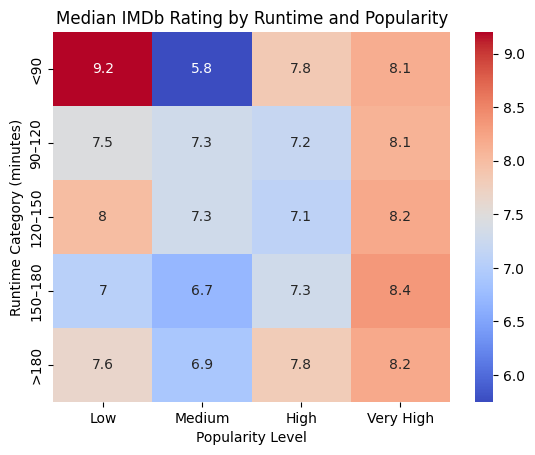

```python
import seaborn as sns
import matplotlib.pyplot as plt

sns.heatmap(pivot_rt_pop, annot=True, cmap="coolwarm")
plt.xlabel("Popularity Level")
plt.ylabel("Runtime Category (minutes)")
plt.title("Median IMDb Rating by Runtime and Popularity")
plt.show()
```

### Popularity Distribution across Genres

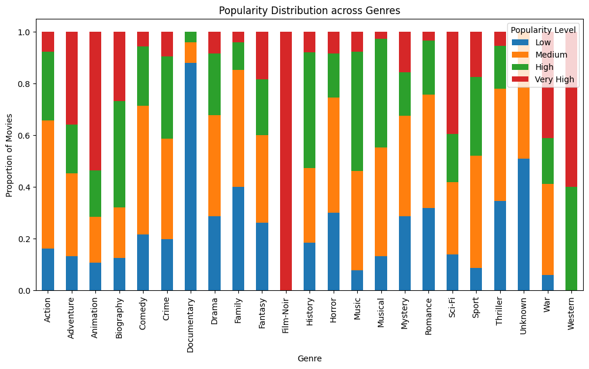

```python
genre_popularity = pd.crosstab(
    df_genre["genre"],
    df_genre["popularity_level"],
    normalize="index"
)

genre_popularity.plot(kind="bar", stacked=True, figsize=(12,6))
plt.xlabel("Genre")
plt.ylabel("Proportion of Movies")
plt.title("Popularity Distribution across Genres")
plt.legend(title="Popularity Level")
plt.show()
```

## HYPOTHESIS 1: Director’s Success Depends on Genre

#### Does a director tend to achieve higher success in certain genres

##### Hypotheses

- H₀: A director’s movie success is independent of genre.
- H₁: A director’s movie success is associated with genre

##### Statistical Test

Chi-Square Test

```python
director_name = "Christopher Nolan"

df_dir = df_genre[df_genre["director"] == director_name]
```

```python
df_dir["genre"].value_counts()
```

```
genre
Action       3
Adventure    3
Sci-Fi       2
Drama        2
Crime        1
Fantasy      1
Name: count, dtype: int64
```

```python
valid_genres = df_dir["genre"].value_counts()
valid_genres = valid_genres[valid_genres >= 2].index

df_dir = df_dir[df_dir["genre"].isin(valid_genres)]
```

```python
df_dir["success"] = df_dir["imdb_rating"].apply(
    lambda x: "Successful" if x >= 7.5 else "Not Successful")
```

```python
import pandas as pd

contingency_table = pd.crosstab(
    df_dir["genre"],
    df_dir["success"]
)

contingency_table
```

| success genre | Not Successful | Successful |
| --- | --- | --- |
| Action | 1 | 2 |
| Adventure | 1 | 2 |
| Drama | 0 | 2 |
| Sci-Fi | 0 | 2 |

```python
from scipy.stats import chi2_contingency

chi2, p_value, dof, expected = chi2_contingency(contingency_table)

print("Chi-square statistic:", chi2)
print("p-value:", p_value)

if p_value < 0.05:
    print("Reject H₀ → Director’s success depends on genre")
else:
    print("Fail to reject H₀ → No strong genre-specific success")
```

```
Chi-square statistic: 1.6666666666666667
p-value: 0.6443698056370253
Fail to reject H₀ → No strong genre-specific success
```

## HYPOTHESIS 2: Movie Runtime Category Influences IMDb Rating

#### Does the duration of a movie significantly influence audience ratings?

##### Hypotheses

- H₀: Mean IMDb ratings are equal across different runtime categories
- H₁: At least one runtime category has a significantly different mean IMDb rating.

##### Statistical Test

One-way ANOVA

```python
from scipy.stats import f_oneway

runtime_groups = [
    df[df["runtime_bin"] == cat]["imdb_rating"]
    for cat in df["runtime_bin"].dropna().unique()
]

f_stat_2, p_value_2 = f_oneway(*runtime_groups)

print("Hypothesis 2: Runtime Category vs IMDb Rating")
print("F-statistic:", f_stat_2)
print("p-value:", p_value_2)

if p_value_2 < 0.05:
    print("Reject H₀ → Ratings differ across runtime categories")
else:
    print("Fail to reject H₀ → No significant difference in ratings")
```

```
Hypothesis 2: Runtime Category vs IMDb Rating
F-statistic: 9.568628777806259
p-value: 1.1579140223037115e-07
Reject H₀ → Ratings differ across runtime categories
```

## HYPOTHESIS 3: Movie Genre Influences IMDb Rating

#### Does Genre of a Movie impact on ratings

Drama-oriented genres appeared to have higher median ratings than action or comedy genres.

##### Hypotheses

- H₀: Mean IMDb ratings are equal across all movie genres.
- H₁: At least one genre has a significantly different mean IMDb rating.

##### Statistical Test

One-way ANOVA

```python
from scipy.stats import f_oneway

genre_groups = [
    df_genre[df_genre["genre"] == g]["imdb_rating"]
    for g in df_genre["genre"].dropna().unique()
]

f_stat_3, p_value_3 = f_oneway(*genre_groups)

print("Hypothesis 3: Genre vs IMDb Rating")
print("F-statistic:", f_stat_3)
print("p-value:", p_value_3)

if p_value_3 < 0.05:
    print("Reject H₀ → Ratings differ significantly across genres")
else:
    print("Fail to reject H₀ → No significant genre-level difference")
```

```
Hypothesis 3: Genre vs IMDb Rating
F-statistic: 12.13238723882381
p-value: 2.1277439278346605e-42
Reject H₀ → Ratings differ significantly across genres
```

[figure not shown]

[figure not shown]

```python
import matplotlib.pyplot as plt

plt.figure(figsize=(20,12))


plt.subplot(2,3,1)
plt.hist(df["imdb_rating"], bins=20)
plt.title("IMDb Rating Distribution")
plt.xlabel("IMDb Rating")
plt.ylabel("Count")

plt.subplot(2,3,2)
df["popularity_level"].value_counts().plot(kind="bar")
plt.title("Popularity Distribution")
plt.xlabel("Popularity Level")
plt.ylabel("Count")


plt.subplot(2,3,3)
plt.hist(df["runtime_minutes"], bins=20)
plt.title("Runtime Distribution")
plt.xlabel("Runtime (minutes)")
plt.ylabel("Count")


plt.subplot(2,3,4)
runtime_rating.plot(kind="bar")
plt.title("Median IMDb Rating by Runtime Category")
plt.xlabel("Runtime Category")
plt.ylabel("Median IMDb Rating")

plt.subplot(2,3,5)
rating_dist.plot(kind="bar", stacked=True)
plt.title("Rating Composition across Popularity")
plt.xlabel("Popularity Level")
plt.ylabel("Proportion of Movies")

plt.subplot(2,3,6)
genre_rating.plot(kind="bar")
plt.title("Genre-wise Median IMDb Rating")
plt.xlabel("Genre")
plt.ylabel("Median IMDb Rating")

plt.tight_layout()
plt.show()
```

[figure not shown]

```python
import matplotlib.pyplot as plt

plt.figure(figsize=(20,12))

#Univariate
plt.subplot(2,3,1)
plt.hist(df["imdb_rating"], bins=20)
plt.title("IMDb Rating Distribution")
plt.xlabel("IMDb Rating")
plt.ylabel("Count")

plt.subplot(2,3,2)
df["popularity_level"].value_counts().plot(kind="bar")
plt.title("Popularity Distribution")
plt.xlabel("Popularity Level")
plt.ylabel("Count")

plt.subplot(2,3,3)
plt.hist(df["runtime_minutes"], bins=20)
plt.title("Runtime Distribution")
plt.xlabel("Runtime (minutes)")
plt.ylabel("Count")

#bivariate
plt.subplot(2,3,4)
ax = plt.gca()
runtime_rating.plot(kind="bar", ax=ax)
plt.title("Median IMDb Rating by Runtime Category")
plt.xlabel("Runtime Category")
plt.ylabel("Median IMDb Rating")

plt.subplot(2,3,5)
ax = plt.gca()
rating_dist.plot(kind="bar", stacked=True, ax=ax)
plt.title("Rating Composition across Popularity")
plt.xlabel("Popularity Level")
plt.ylabel("Proportion of Movies")

plt.subplot(2,3,6)
ax = plt.gca()
genre_rating.plot(kind="bar", ax=ax)
plt.title("Genre-wise Median IMDb Rating")
plt.xlabel("Genre")
plt.ylabel("Median IMDb Rating")

plt.tight_layout()
plt.show()
```

[figure not shown]

```python
import matplotlib.pyplot as plt
import seaborn as sns

plt.figure(figsize=(18,6))

plt.subplot(1,2,1)
ax = plt.gca()
sns.heatmap(pivot_rt_pop,annot=True,cmap="coolwarm",ax=ax)
plt.title("Median IMDb Rating by Runtime and Popularity")
plt.xlabel("Popularity Level")
plt.ylabel("Runtime Category")


plt.subplot(1,2,2)
ax = plt.gca()
genre_popularity.plot(kind="bar",stacked=True,ax=ax)
plt.title("Popularity Distribution across Genres")
plt.xlabel("Genre")
plt.ylabel("Proportion of Movies")

plt.tight_layout()
plt.show()
```